# National MENTOR Program Report

## Please estimate the percentage of youth in this program that are.

### Black, Afro-Caribbean, or African American

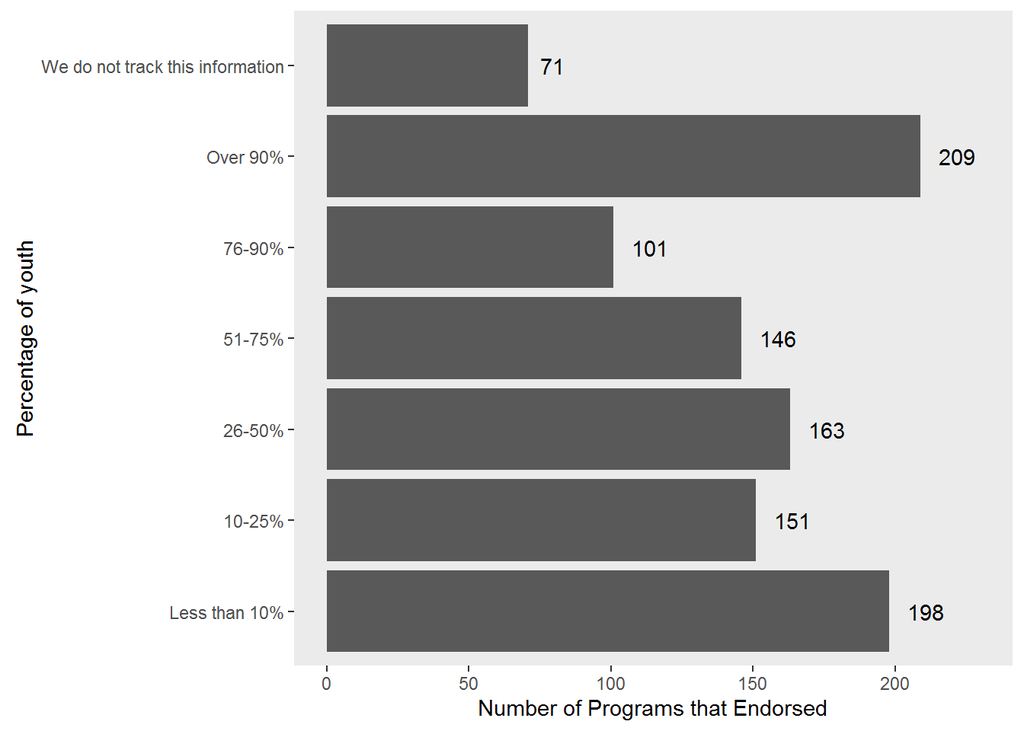

### East Asian or Asian American

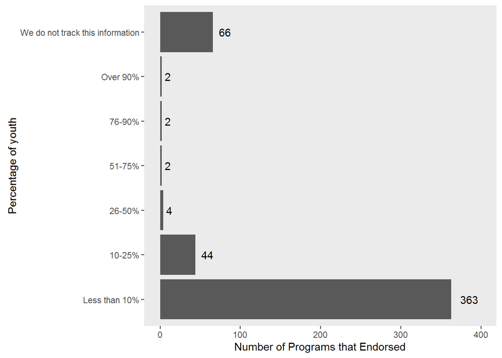

### Hawaiian or Pacific Islander

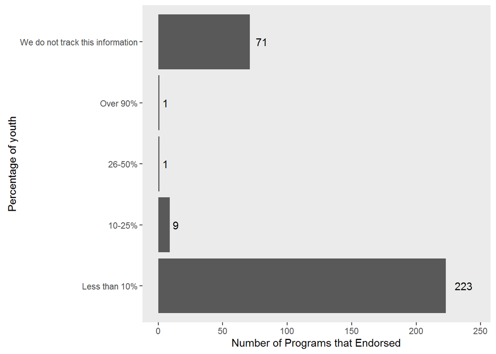

### Latino or Hispanic American

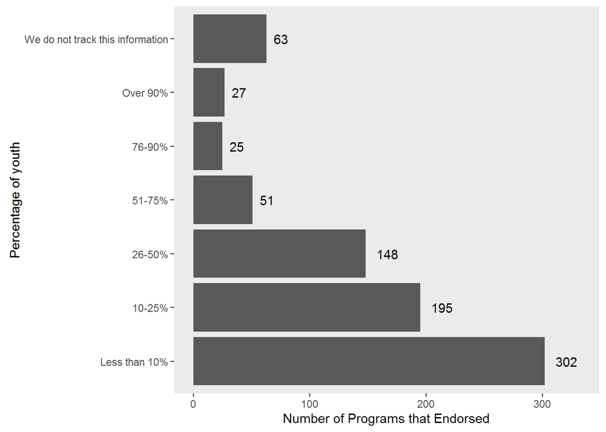

### Middle Eastern or Arab American

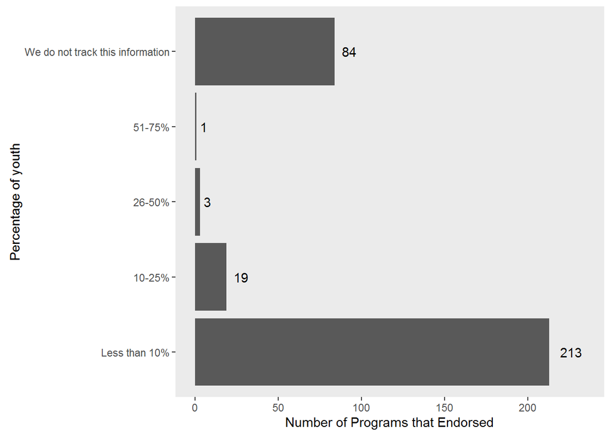

### Native American or Alaskan Native

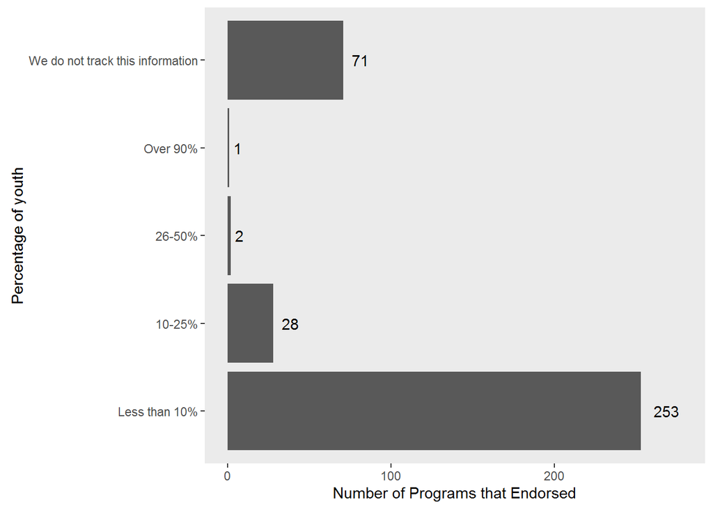

### Non-Hispanic White or Euro-American

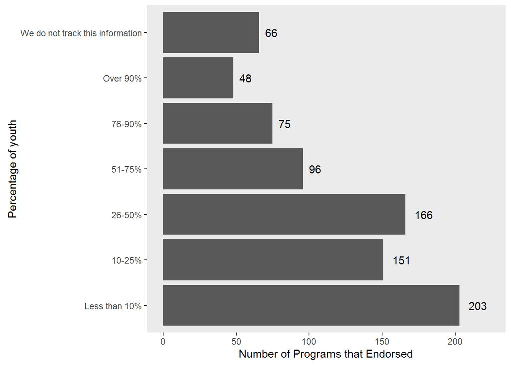

### South Asian or Indian American

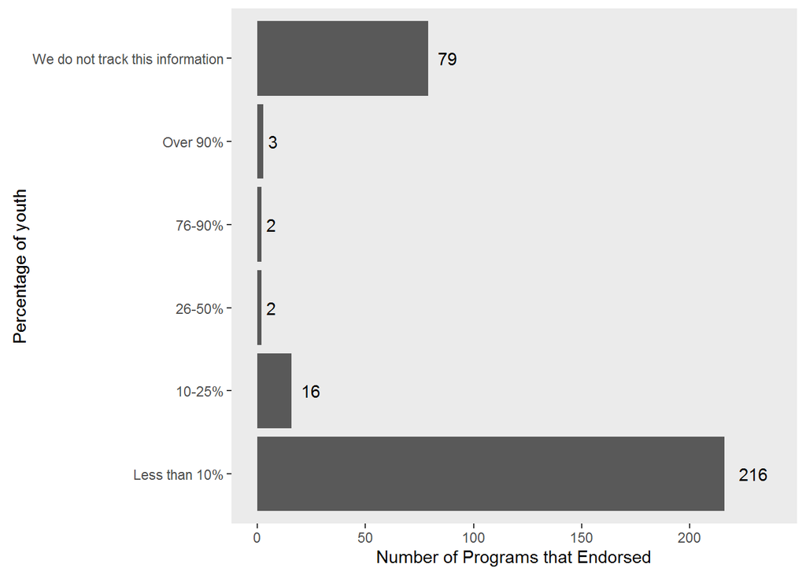

### Multiracial

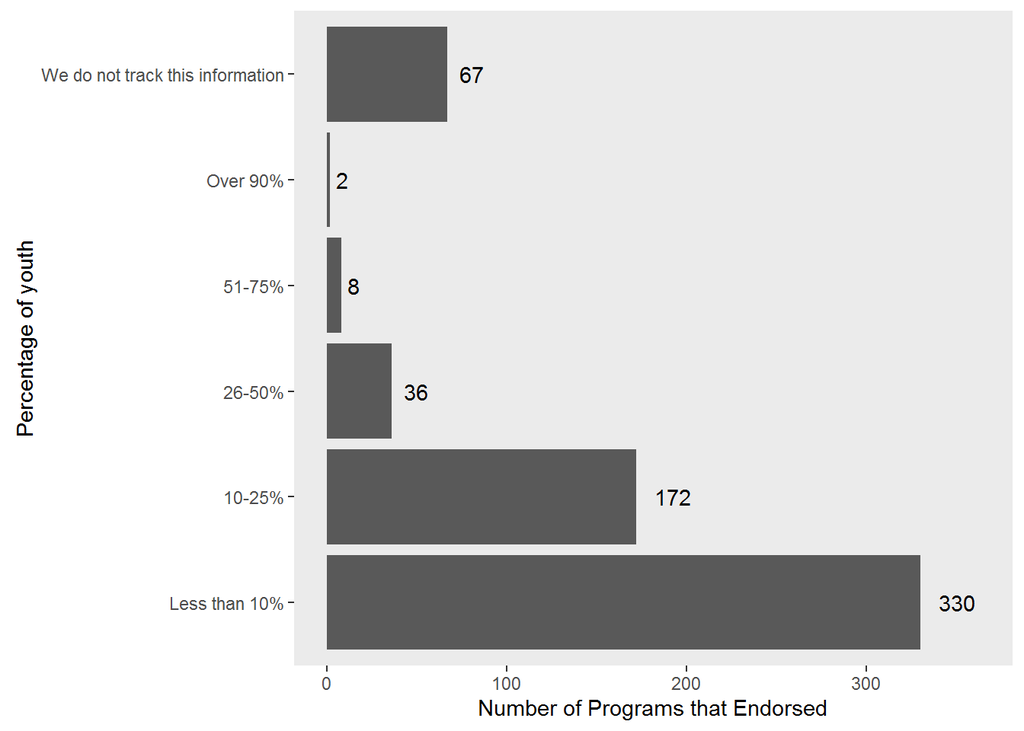

### Other

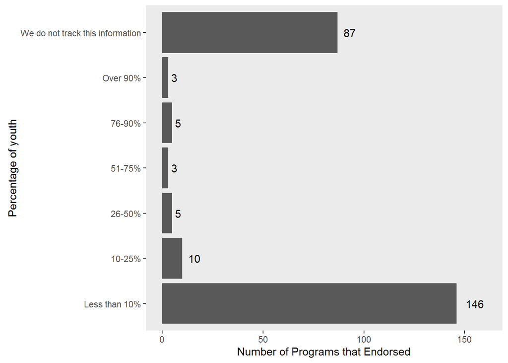

## Please estimate the percentage of this program’s mentees served over the last year that represent the following subgroups.

### Academically at-risk

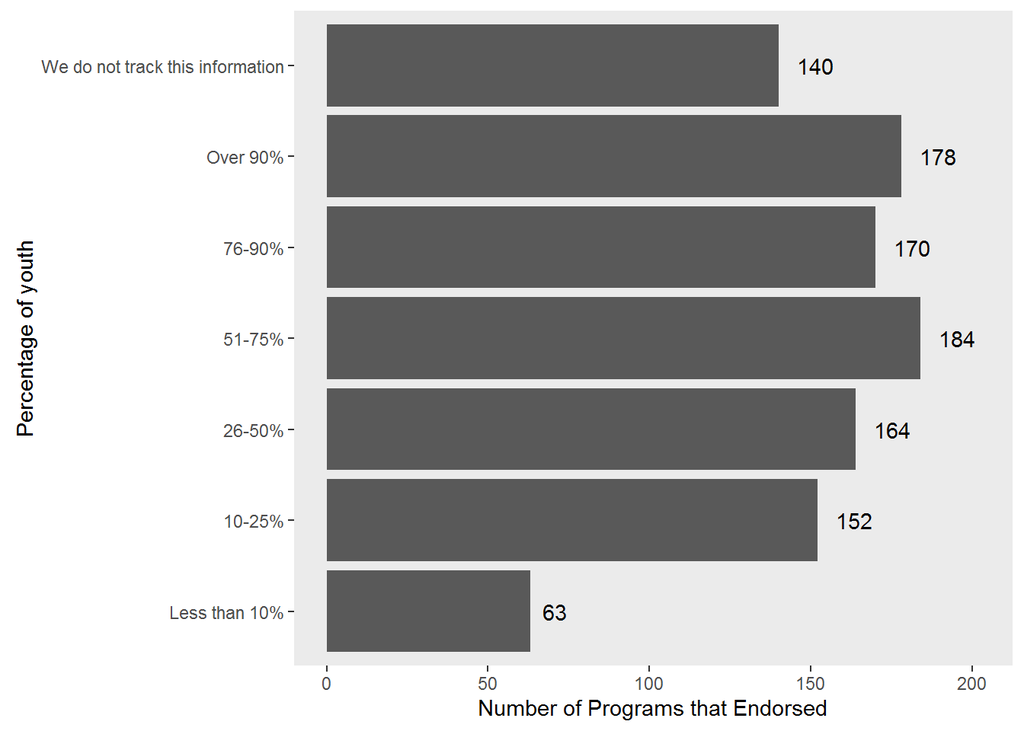

### Adjudicated or juvenile justice-involved

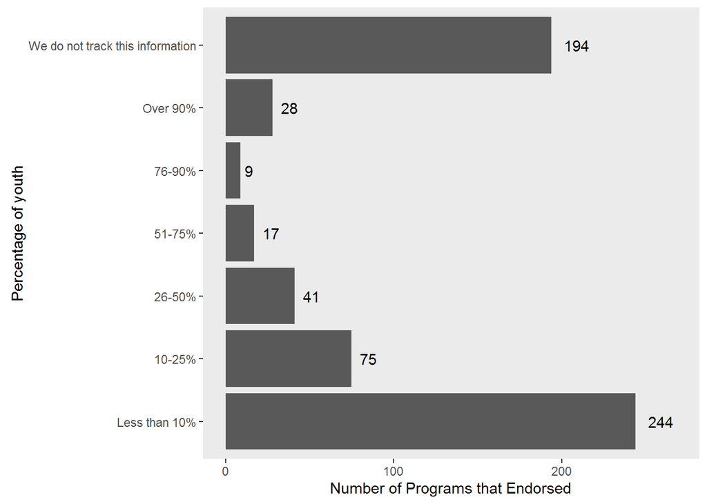

### Disabilities or special health care needs

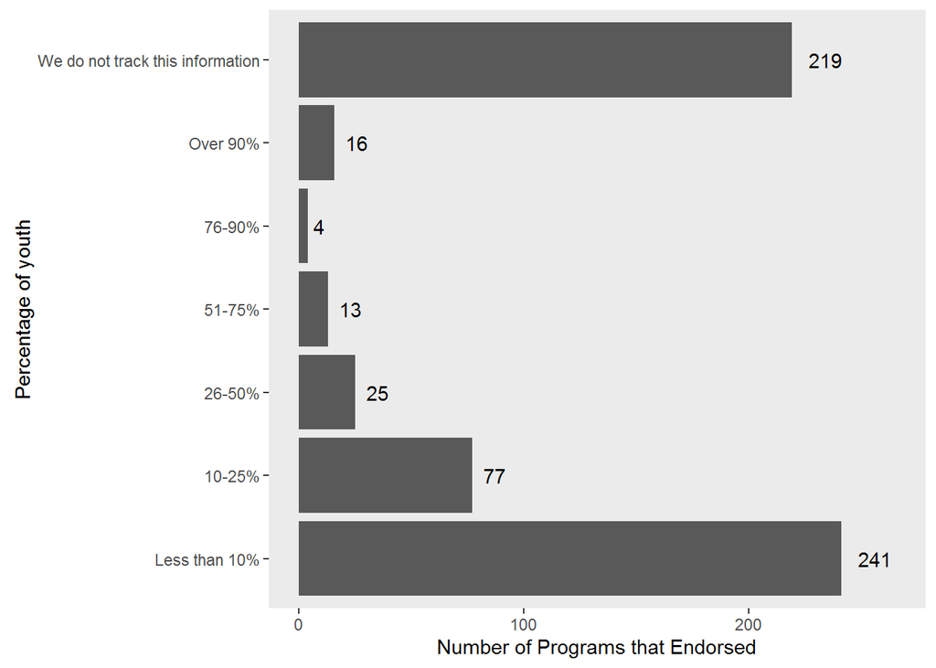

### Enrolled in postsecondary education/college

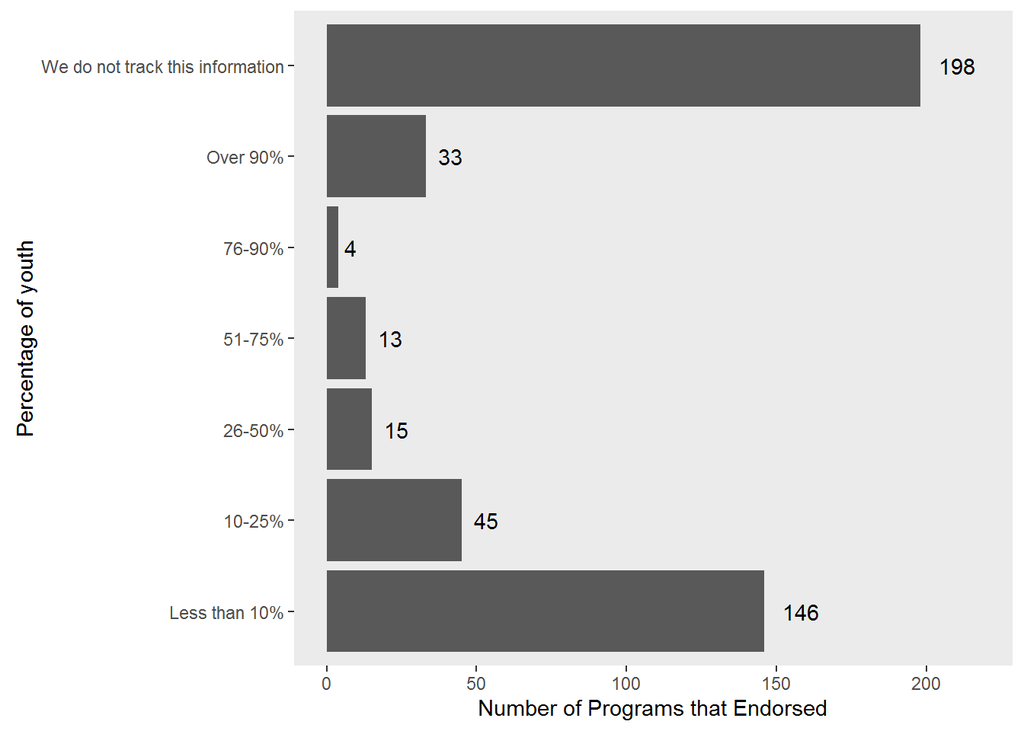

### First generation in family to go to college

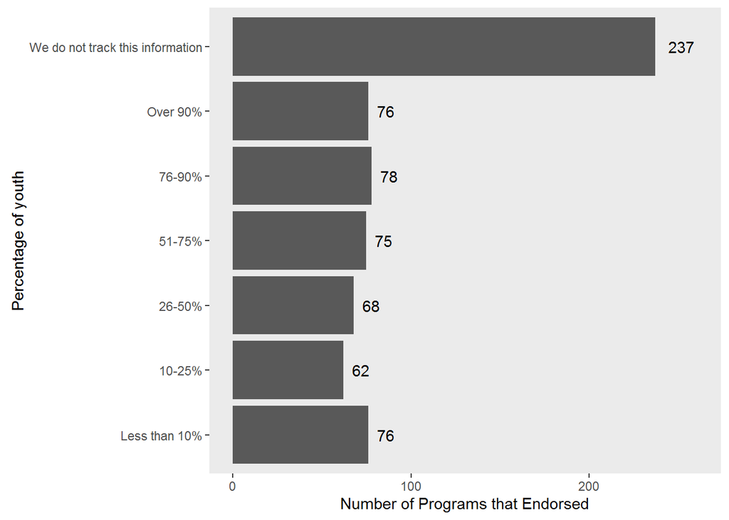

### Foster, residential, or kinship care

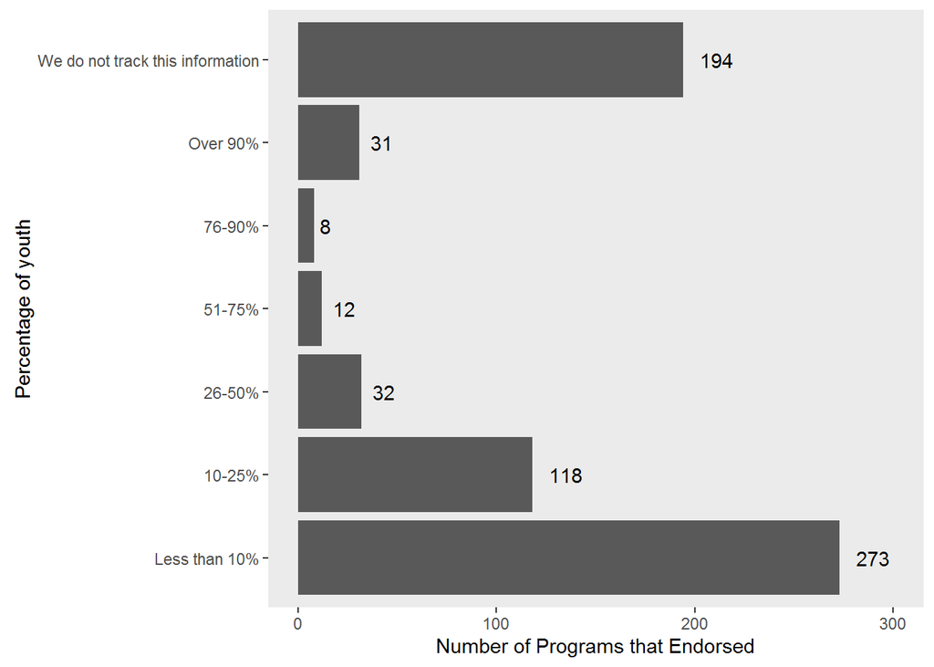

### Gang involved

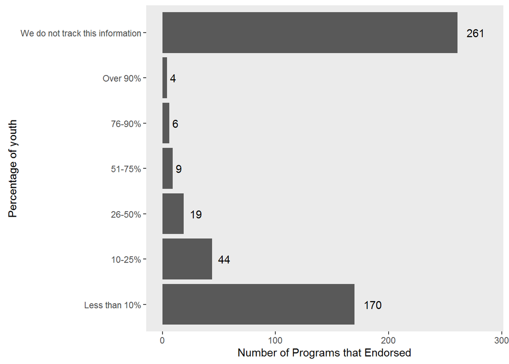

### High academic achievers

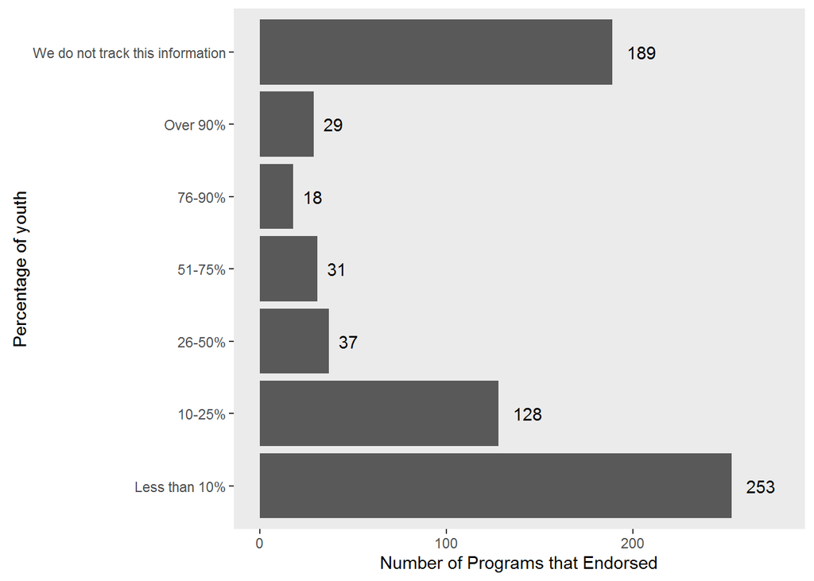

### Incarcerated parent(s) or family members

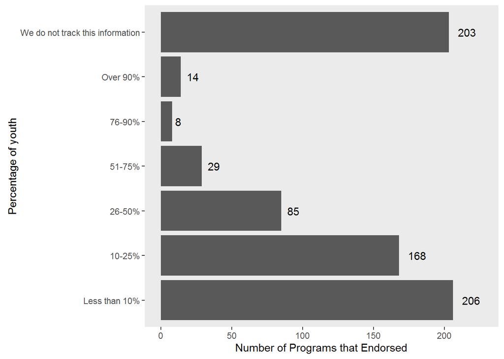

### Left school prematurely

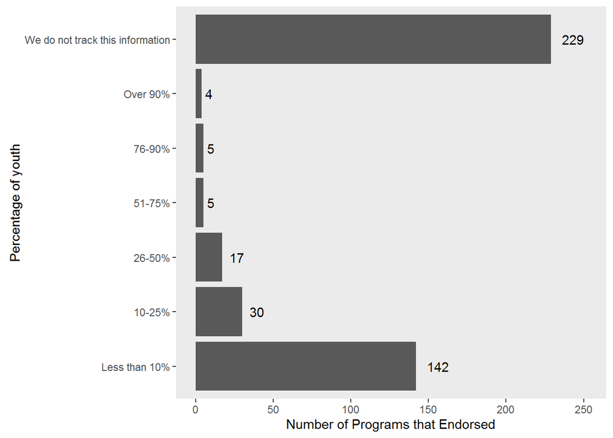

### LGBTQ

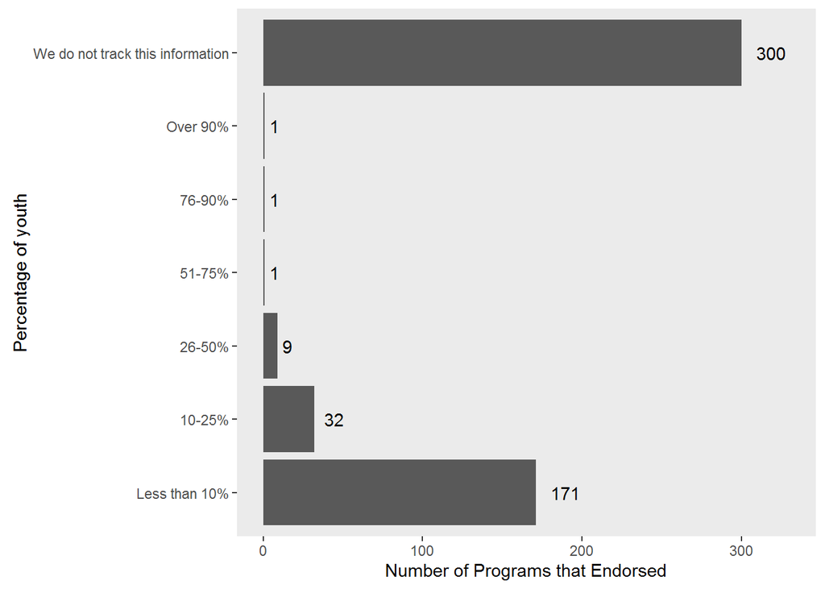

### Low income

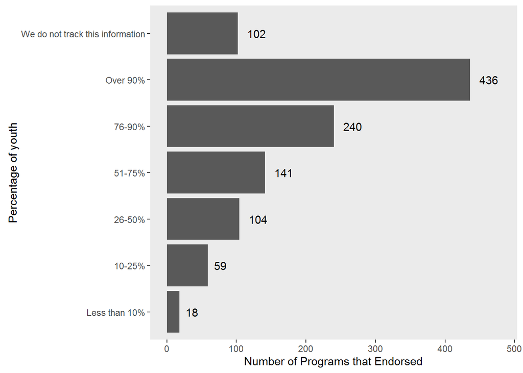

### Mental health needs

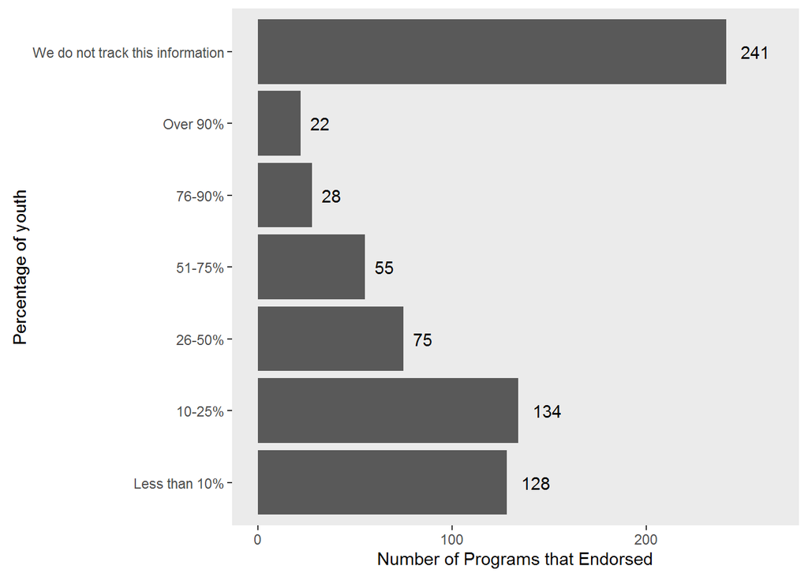

### Military parents

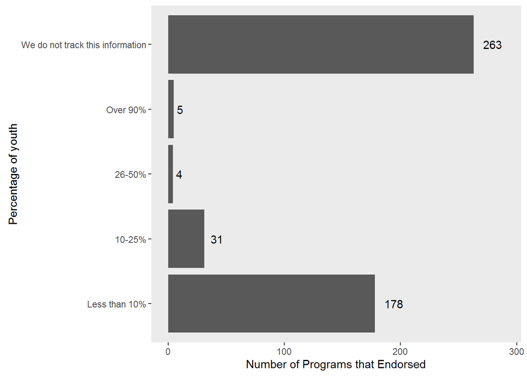

### Pregnant/early parenting

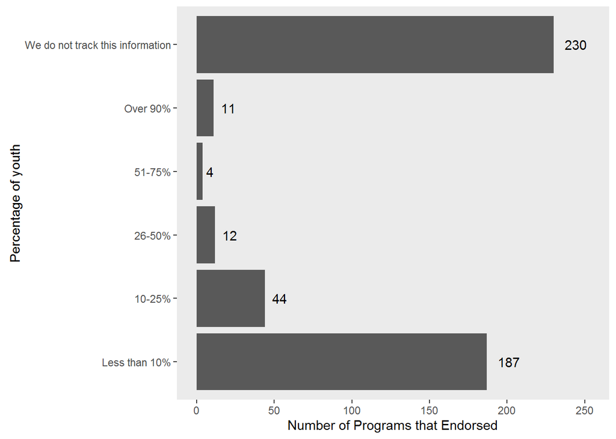

### Receiving special education services in school

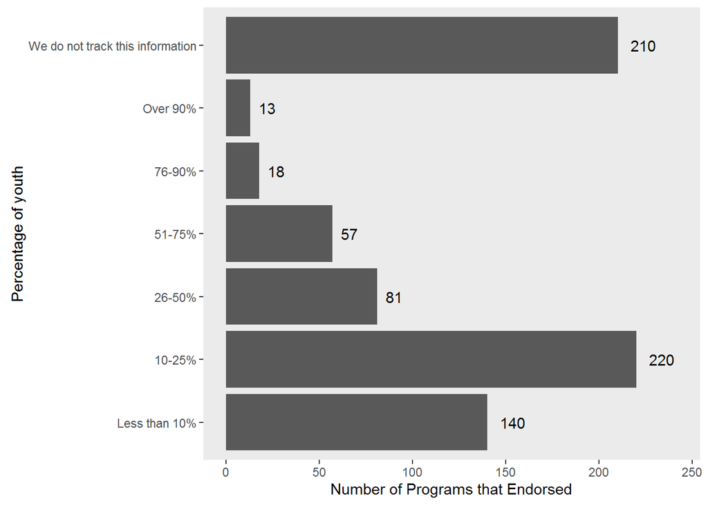

### Recent immigrant or refugee

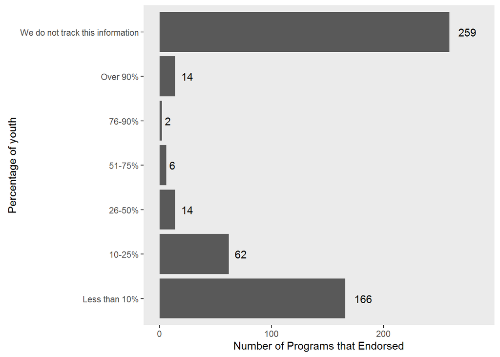

### Runaway/homeless youth

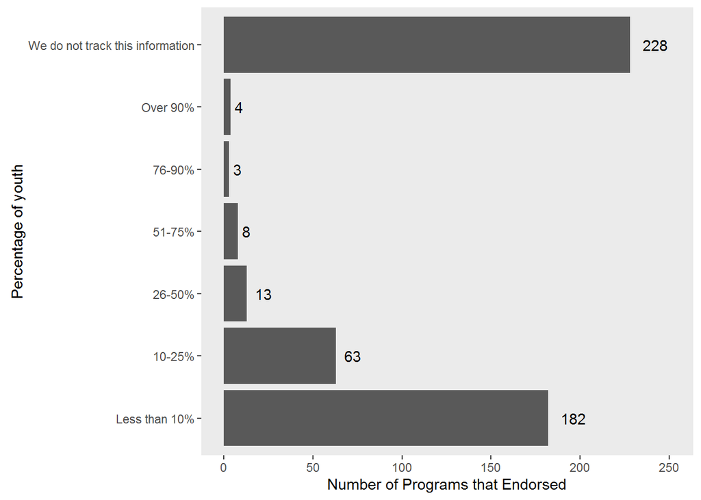

### Single parent household

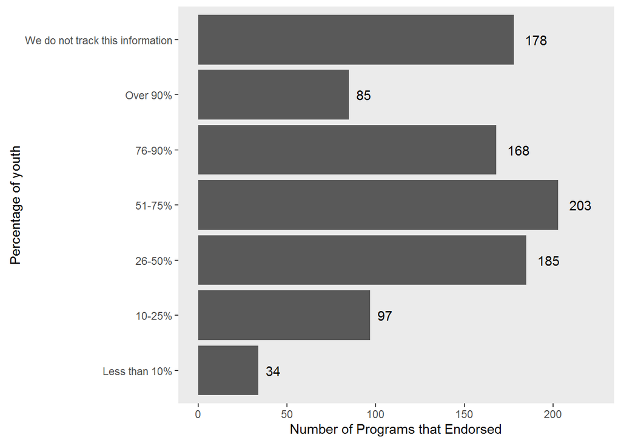

### Truant youth

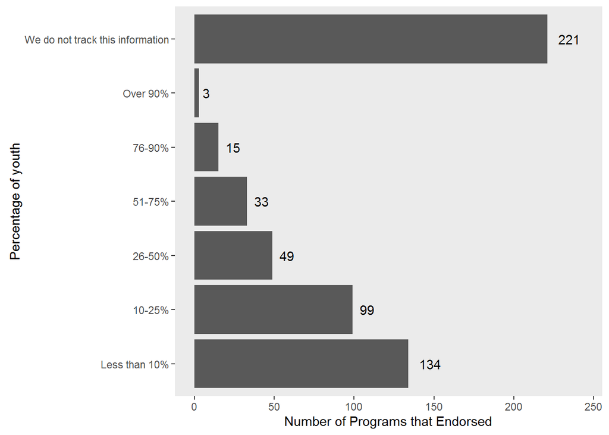

### Victims of commercial sexual exploitation

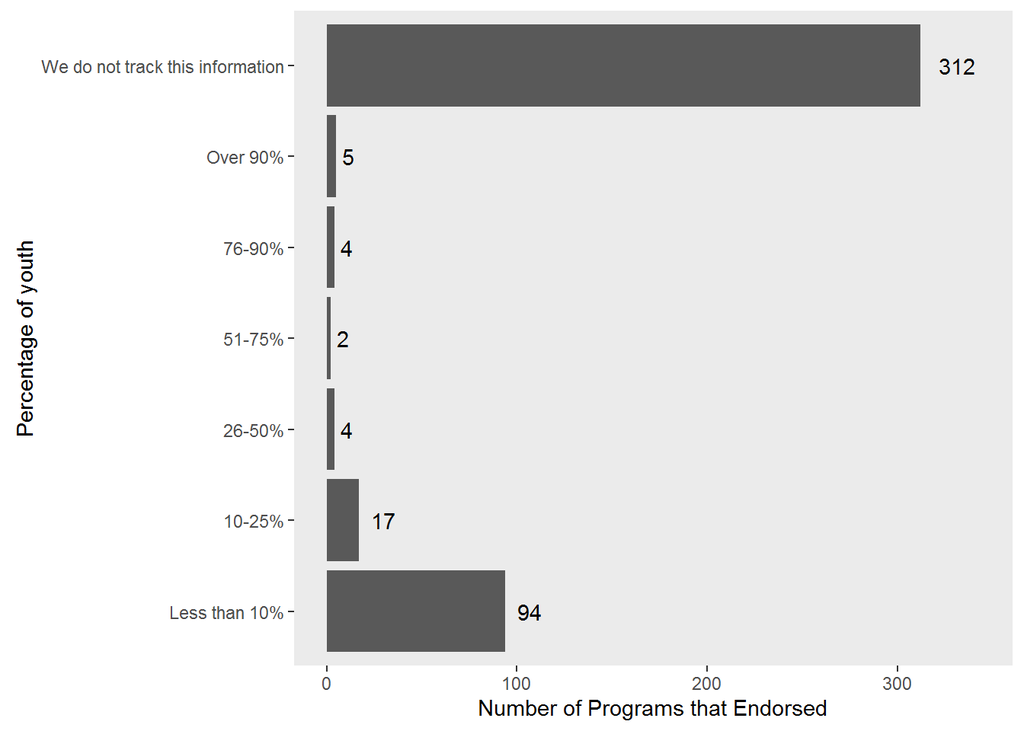

## In the last year, the number of youth served by this program.

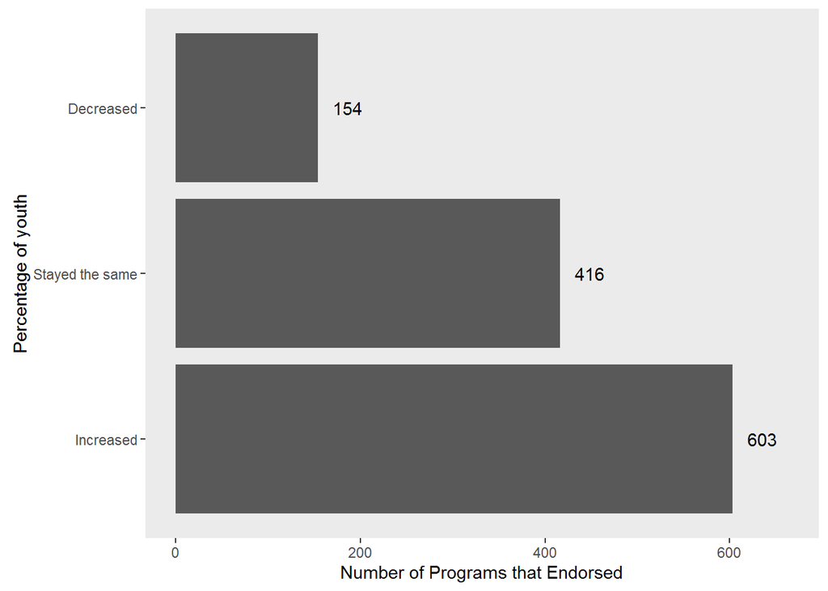

# Program Operating Characteristics

## If the number of youth served increased or decreased, please choose the main causes.

| **Cause** | **Frequency** | **Proportion** |
| --- | --- | --- |
| Change in funding level | 218 | 0.18 |
| Change in available staffing | 193 | 0.16 |
| Change in community interest/demand | 249 | 0.2 |
| Change in number of volunteers recruited | 317 | 0.26 |
| Change in number of youth enrolling | 287 | 0.23 |
| Change in program offerings | 113 | 0.09 |
| Other - Write In | 112 | 0.09 |

## How many youth are currently on a waitlist to be matched with a mentor in this program?

### Transgender female

### -Median: 0

### -Mode: 0

### -Mean: 4.2

### Other identification (gender fluid, agender, genderqueer, etc.)

### -Median: 0

### -Mode: 0

### -Mean: 9.2

## Please estimate the average length of time youth spend on this program’s waitlist to be matched.

### Males

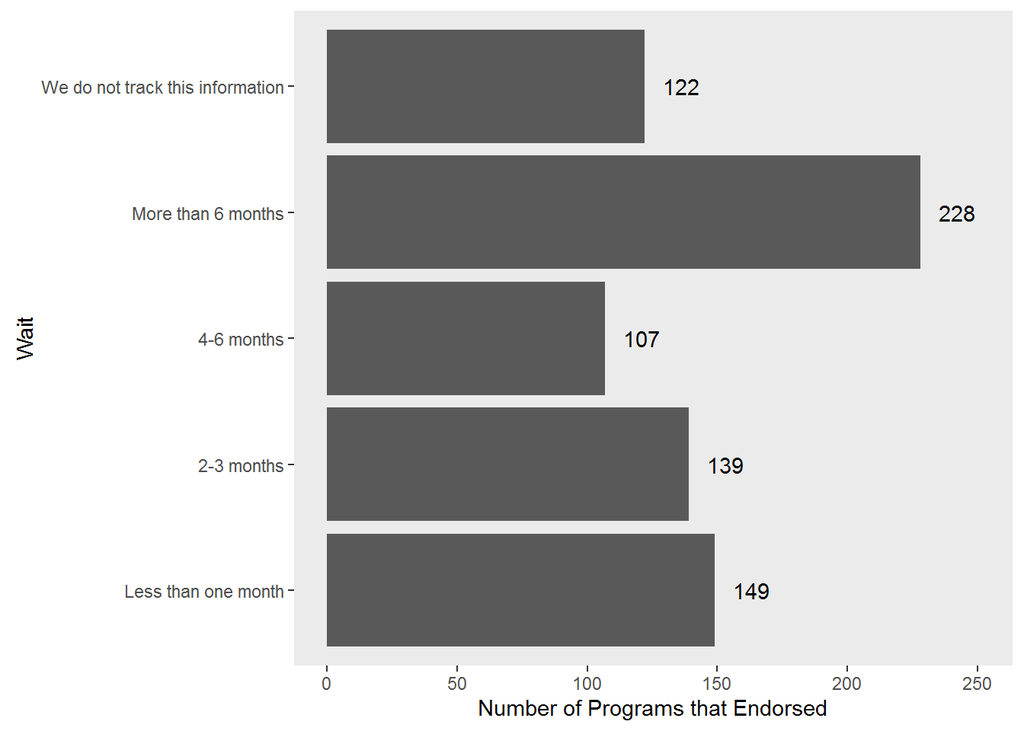

### Females

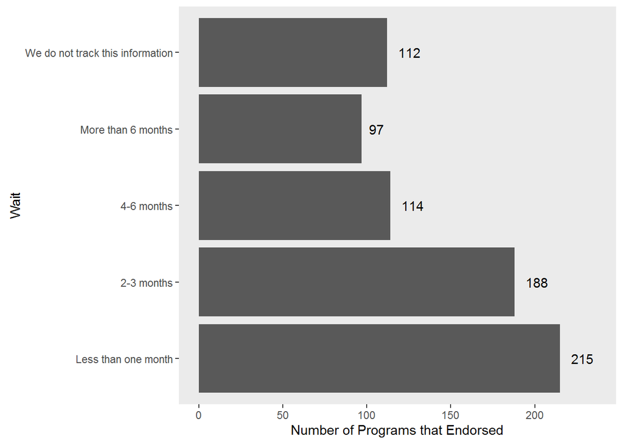

### Transgender Males

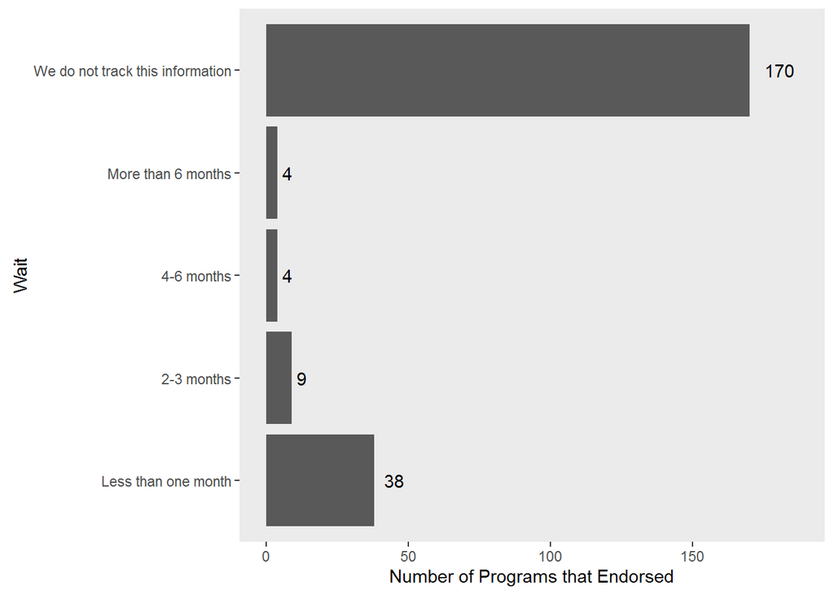

### Transgender Females

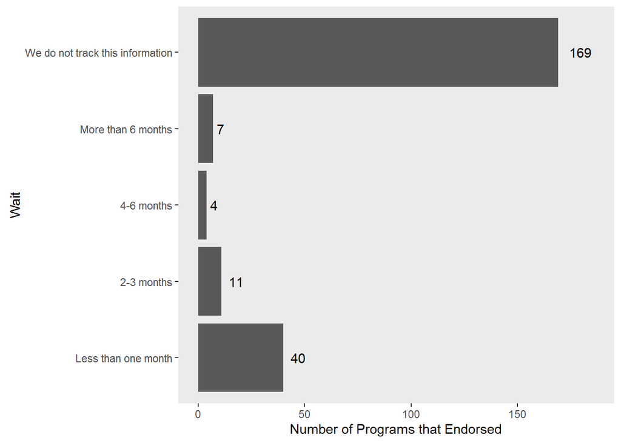

### Other identification (gender fluid, agender, genderqueer, etc.)

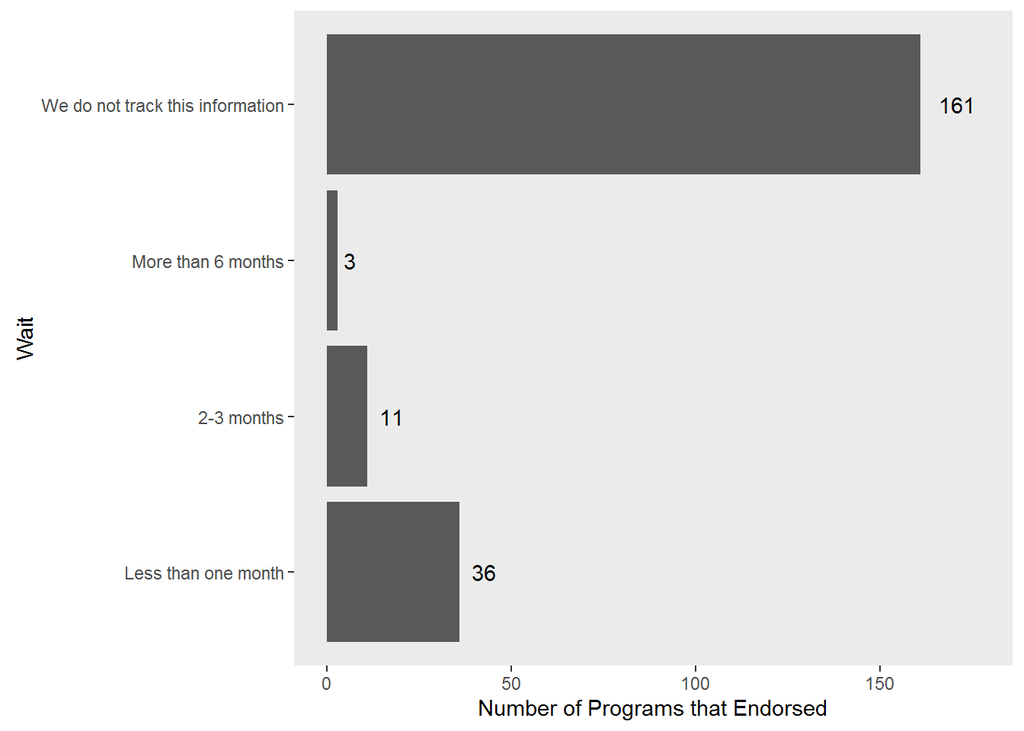

## In the last year, how many individuals served as mentors in this program?

### Male

### -Median: 13

### -Mode: 2

### -Mean: 54.98

### Female

### -Median: 20

### -Mode: 5

### -Mean: 80.46

### Transgender male

### -Median: 0

### -Mode: 0

### -Mean: 4.57

### Transgender female

### -Median: 0

### -Mode: 0

### -Mean: 0.05

### Other identification (gender fluid, agender, genderqueer, etc.)

### -Median: 0

### -Mode: 0

### -Mean: 10.7

## Please estimate the percentage of this program’s mentors over the last year that represent the following subgroups.

### AmeriCorps or other national service related positions

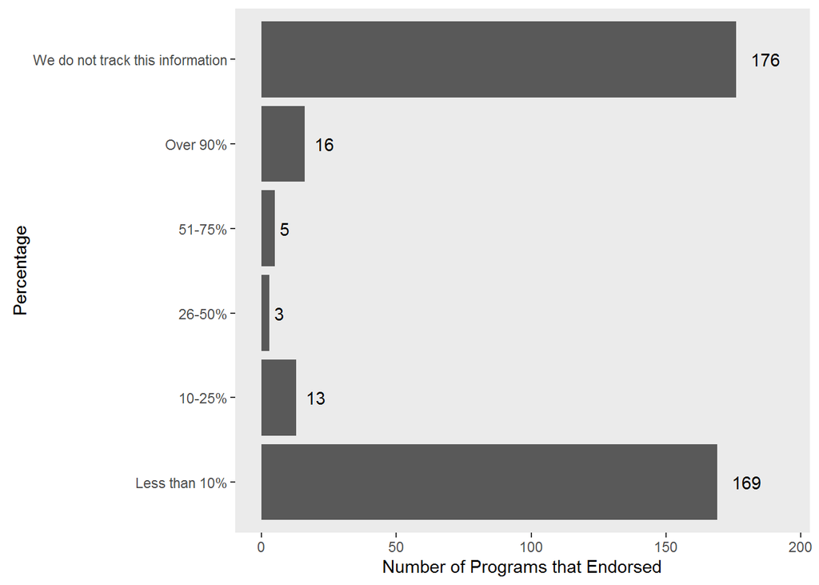

### College students

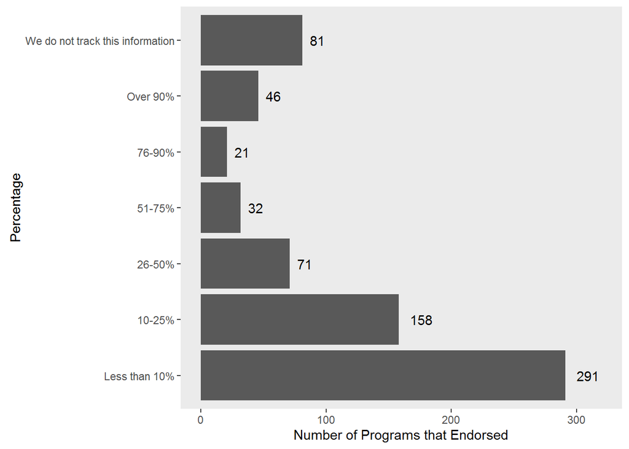

### Employees of corporate partners

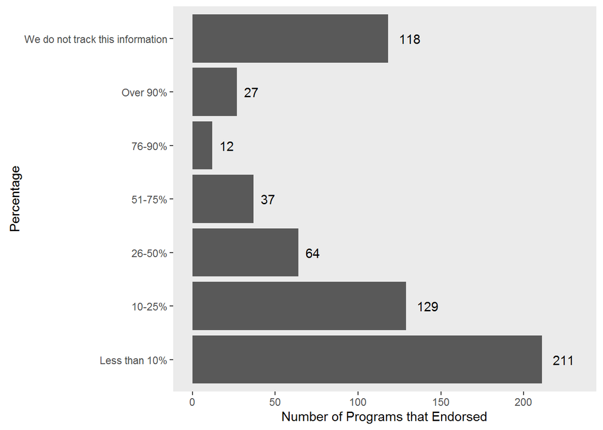

### Employees in a specific, targeted field

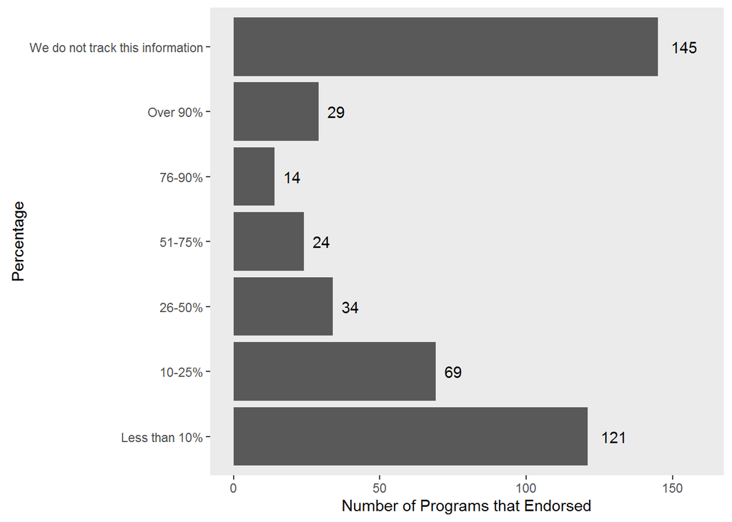

### Former mentees in the program

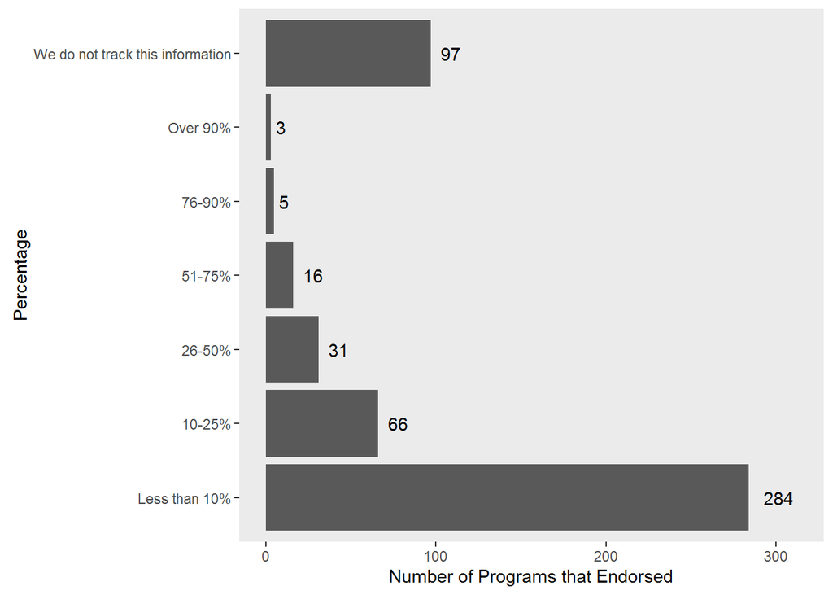

### High school students

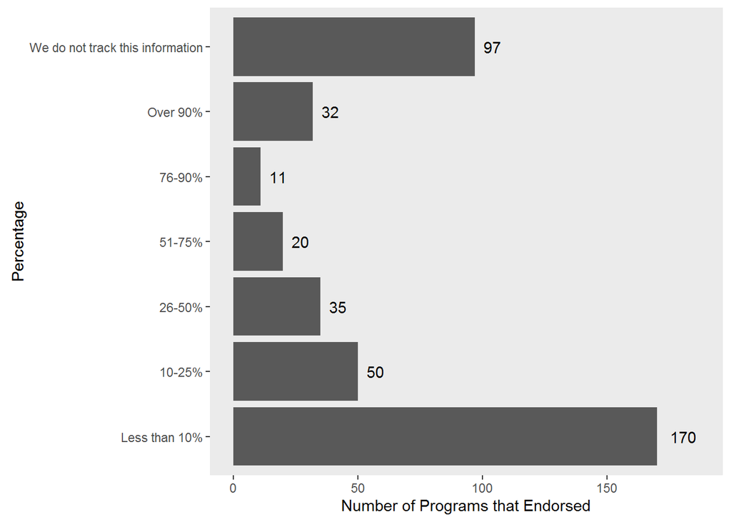

### Local/state government employees

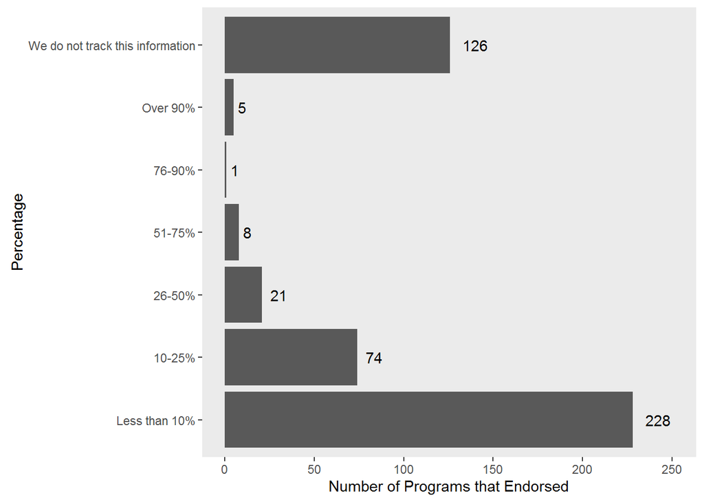

### Members of affinity groups (e.g., civic, cultural, religious, alumni, professional)

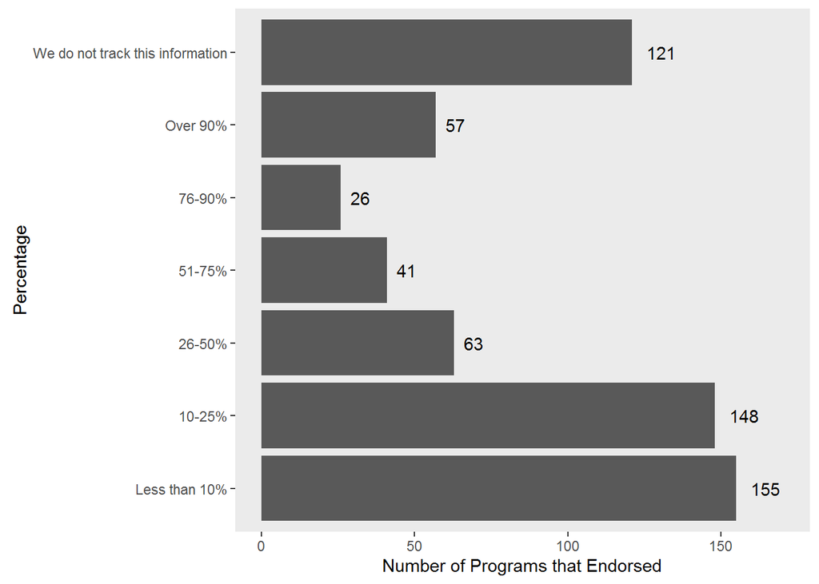

### Middle school students

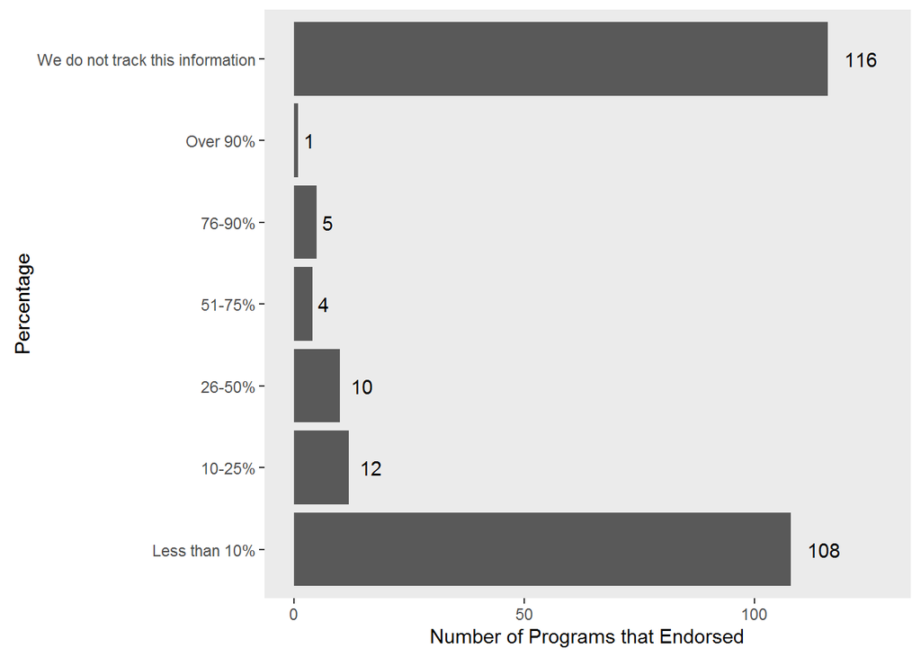

### Nonworking/unemployed persons

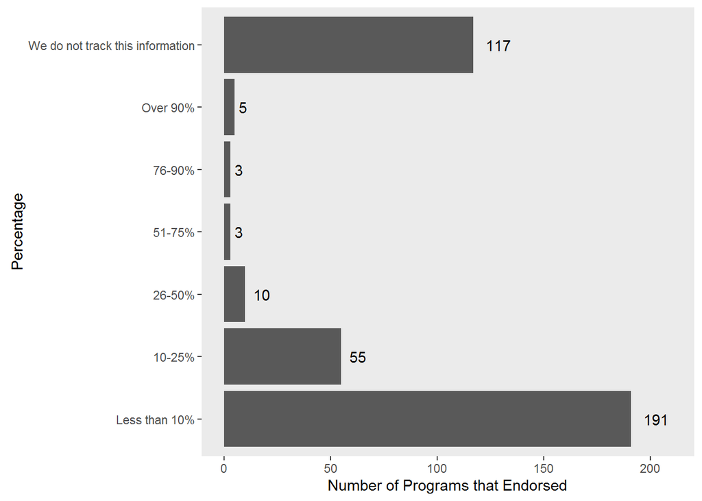

### Retired persons

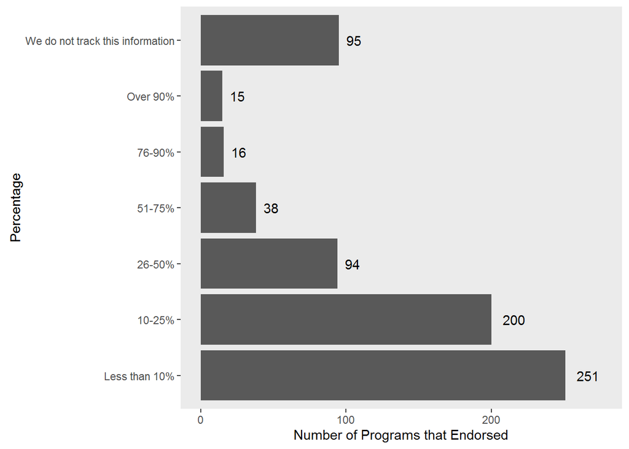

### Spouses co-mentoring

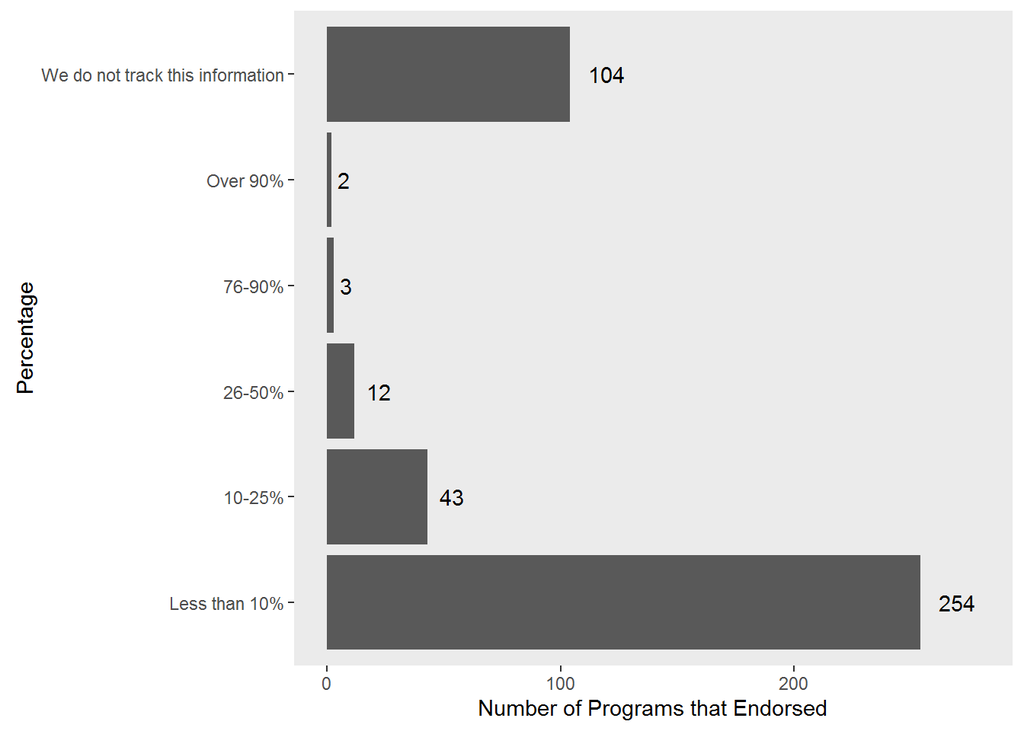

### Teachers/school employees

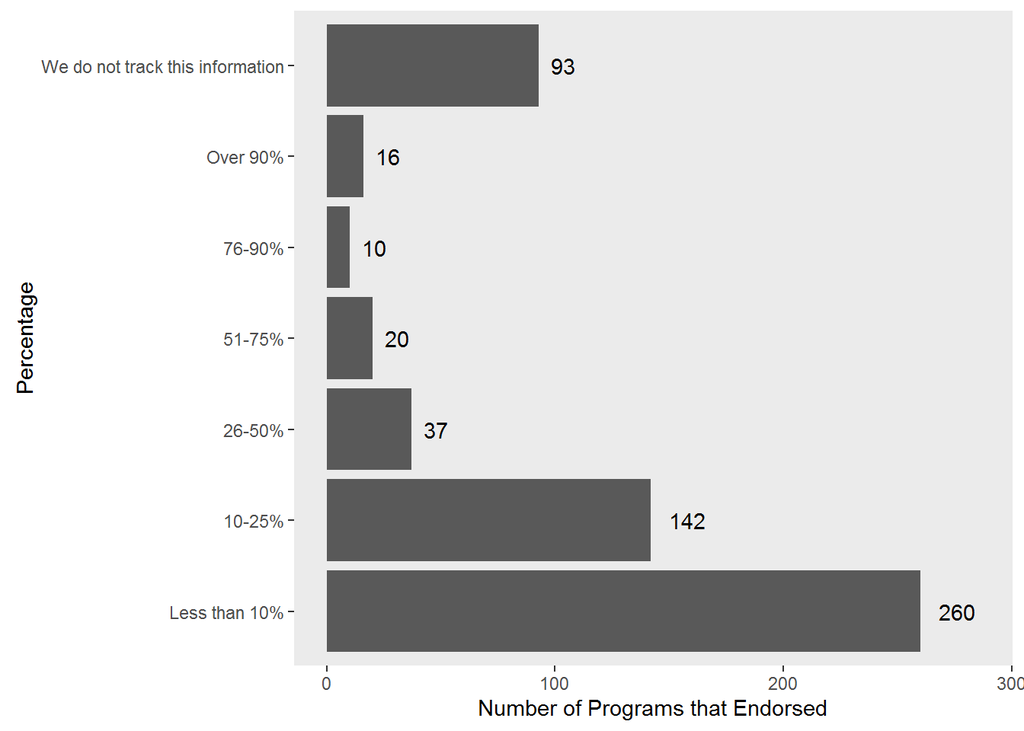

### Young professionals

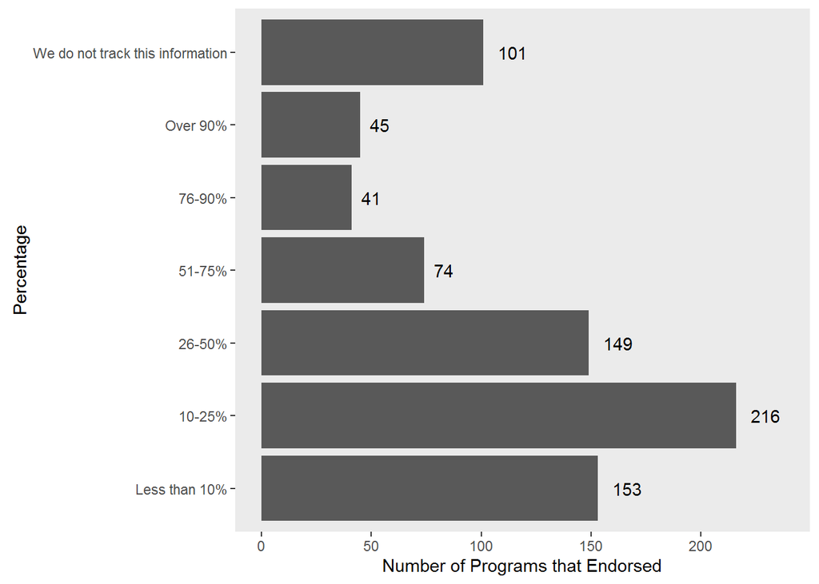

## Please estimate the percentage of mentors in this program that are…

### Black, Afro-Caribbean, or African American

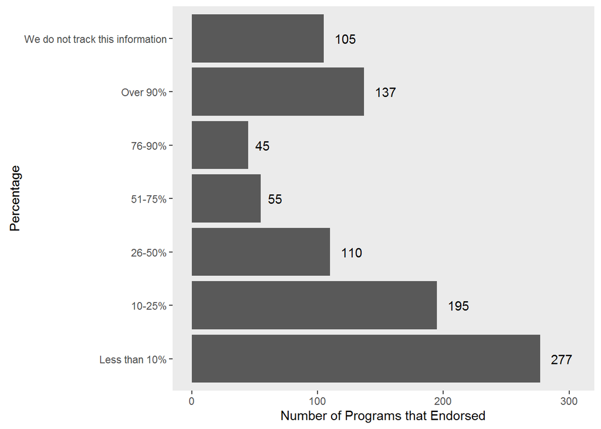

### East Asian or Asian American

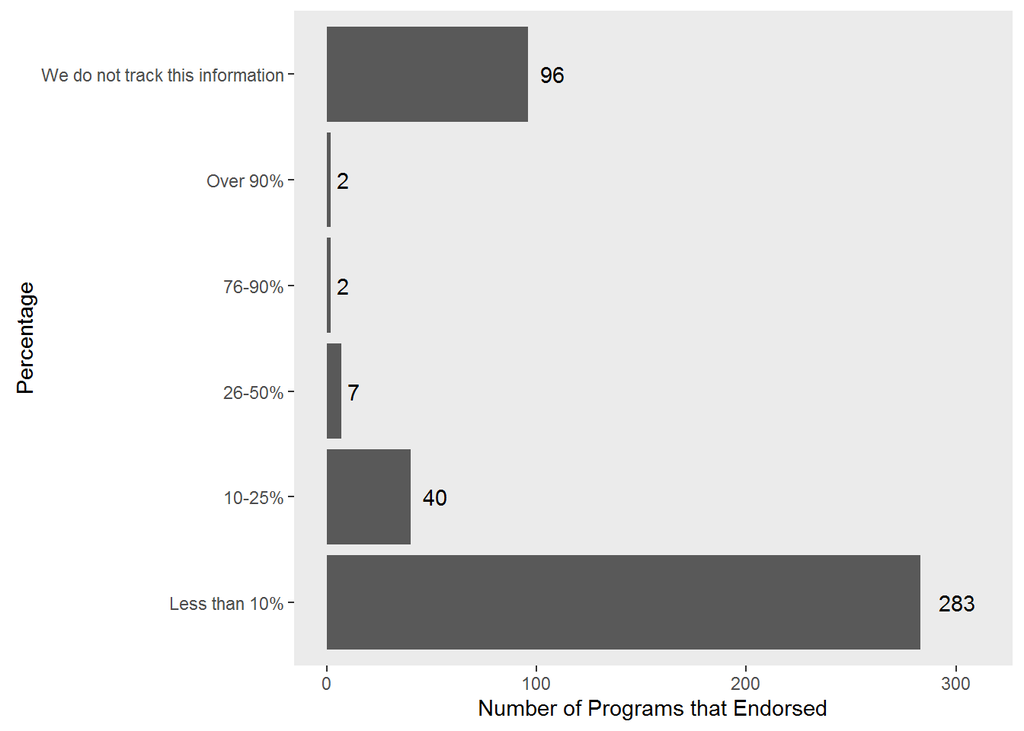

### Hawaiian or Pacific Islander

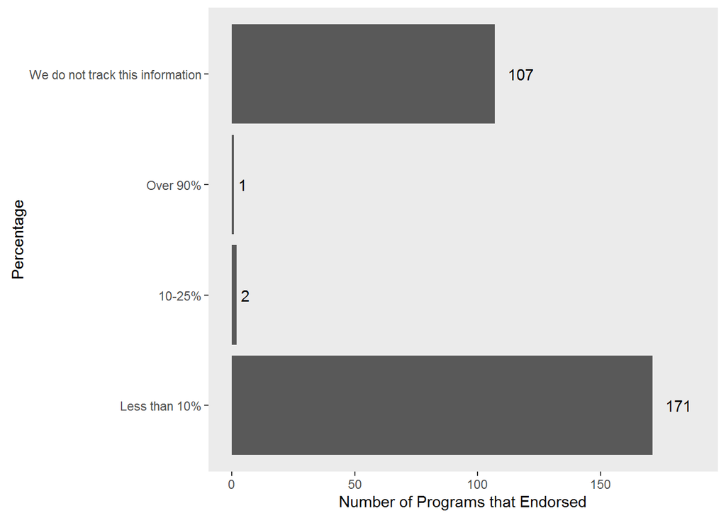

### Latino or Hispanic American

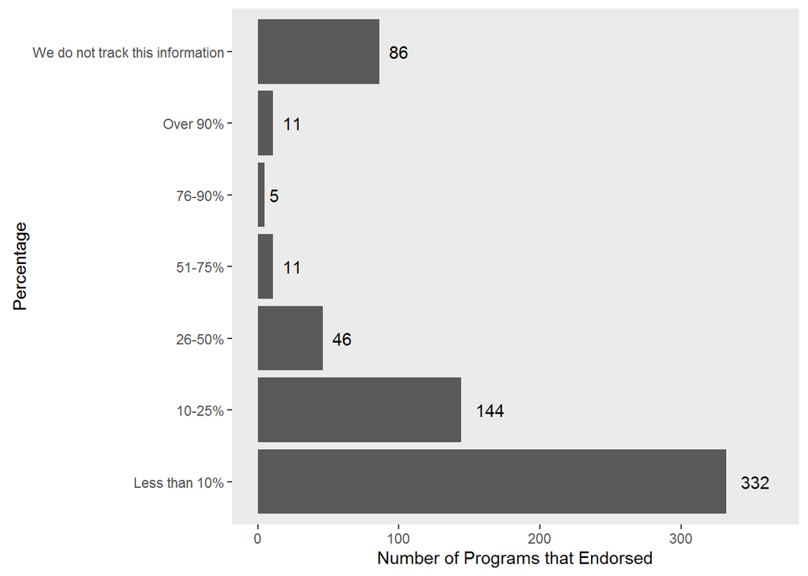

### Middle Eastern or Arab American

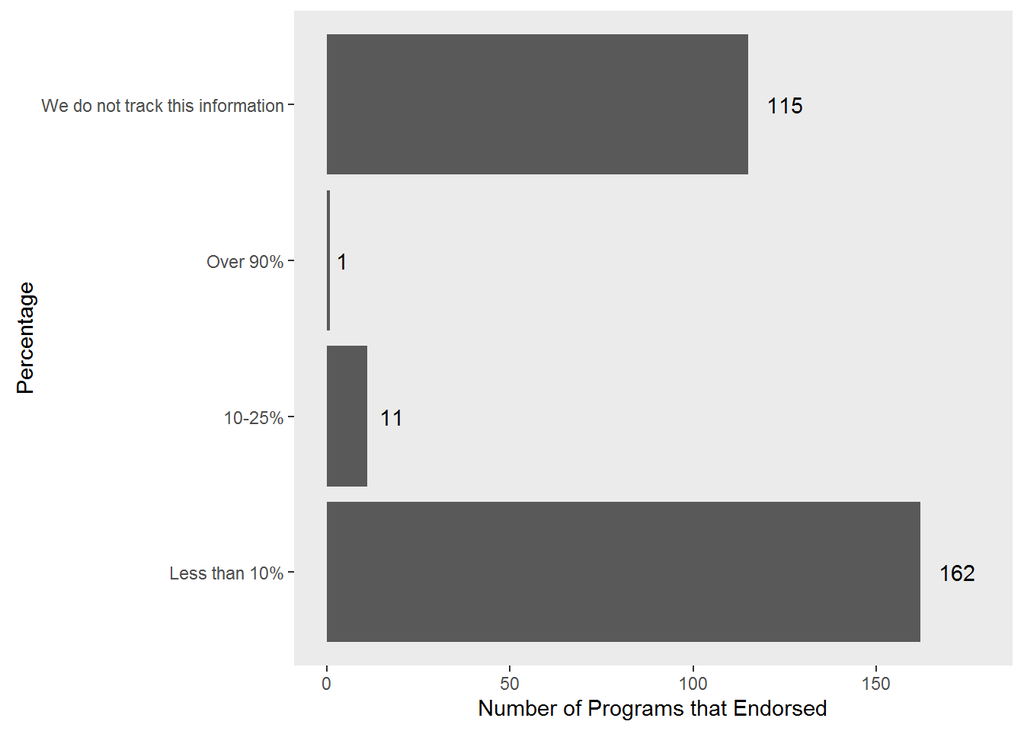

### Native American or Alaskan Native

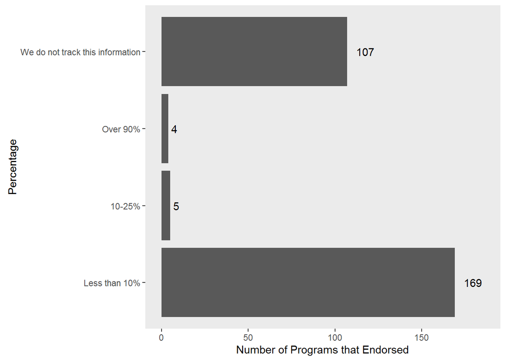

### Non-Hispanic White or Euro-American

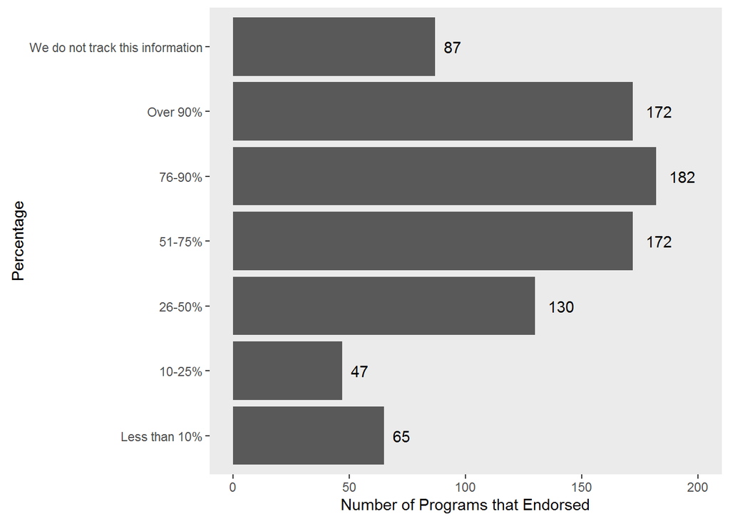

### South Asian or Indian American

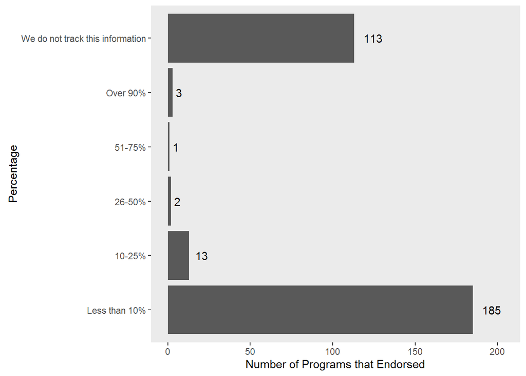

### Multiracial

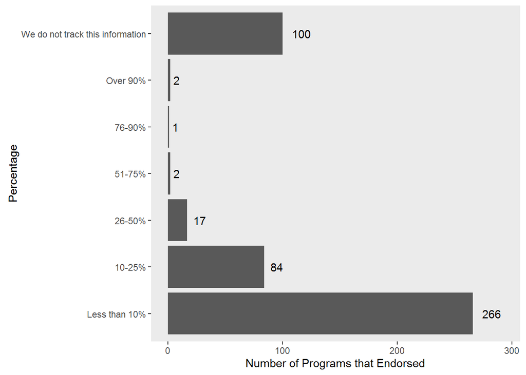

### Other

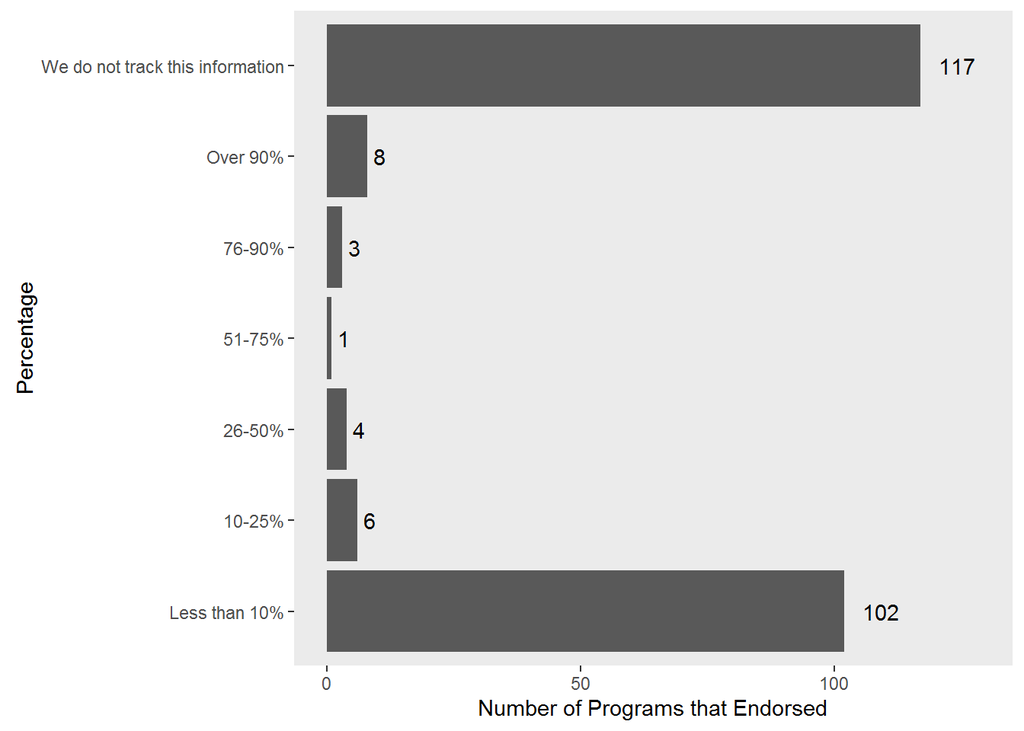

# Training Questions

## On average, how much training are mentors expected receive BEFORE they are matched with mentees?

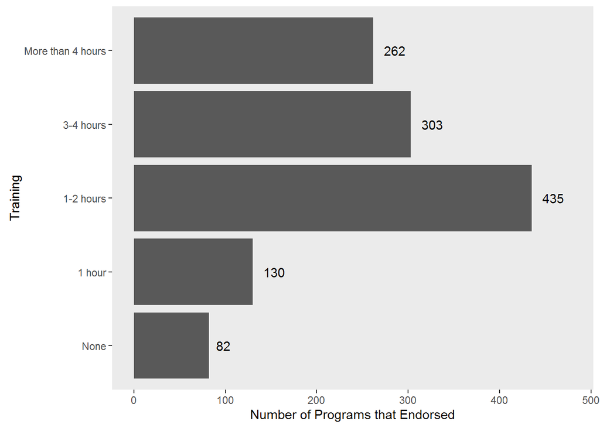

## On average, how much training are mentors expected receive AFTER they are matched with mentees?

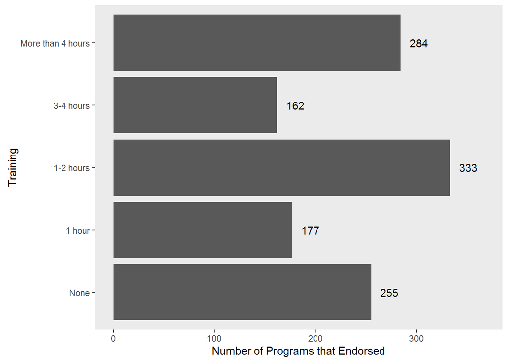